# Retaliation on a voodoo doll symbolizing an abusive supervisor restores justice

A replication based on simulation data to explain the principle of academic writing

Damien Dupré

## Abstract

The present paper is a replication of the paper entitled “Righting a wrong: Retaliation on a voodoo doll symbolizing an abusive supervisor restores justice” (Liang et al., 2018). This academic article was published the journal The Leadership Quartely and has been awarded with the prestigious IG Noble Price section Business Studies. By testing the hypotheses formulated by its authors on simulated data, the present paper will describe each steps of the academic writing.

# Introduction

Abusive supervision is a problem for the mental well-being of employees. In case of behaviours charactering an abusive supervision such as such as public ridicule, yelling, scapegoating, or other forms of supervisor mistreatment, employees will have to deploy coping-mechanisms in order to preserve enough motivation to work in this negative environment. The predicate of the paper *Righting a wrong: Retaliation on a voodoo doll symbolizing an abusive supervisor restores justice* is that “a natural response for the subordinate is to directly retaliate against the abusive supervisor” (Liang et al., 2018, p. 443). This predicate is probably what made the paper published by Liang et al. (2018) an excellent candidate for the IG Nobel. However, this paper has an excellent structure and a very robust method. For these reason, it will be used as example of how to write an academic paper.

The first step of an academic paper is the Introduction section which is supposed 1) to present the problem that the paper is trying to understand and 2) to end with the authors research question. Here the research question of Liang et al. (2018) is probably the following: How abusive supervision and the subordinate retaliation influence the subordinate injustice perception.

# Literature Review

The literature review is used to describe each concept included in the research question independently in specific subsections. It aims to give a short and an uptodate presentation of the current states the research involving these concepts with some example of results obtained in these research. Here, there are three concepts to investigate: abusive supervision, subordinate retaliation and subordinate injustice perception.

## Abusive Supervision

The goal of the present paper is to describe the process of academic writing and not to investigate any kind of abusive supervision, subordinate retaliation or subordinate injustice perception. This subsection is only an example of how to structure these subsections.

## Subordinate Retaliation

The most important content of the literature review is the formulation of hypotheses. These hypotheses can be implicitly formulated in the body of the literature review but a common and efficient way to present the hypotheses is explicitly at the end of the literature review.

**Hypothesis 1**: *The average injustice perception in the condition of abusive supervision is higher than the average injustice perception in the condition of non-abusive supervision.*

**Hypothesis 2**: *The injustice perception decrease when the subordinate retaliation increase.*

**Hypothesis 3**: *The effect of subordinate retaliation on injustice perception in the condition of abusive supervision is higher than in the condition of non-abusive supervision*

# Method

The method section usually describes the participants/observations, the material used to collect the data, the procedure followed by the authors and the analyses performed.

## Material

The method that Liang et al. (2018) used to measure **subordinate retaliation** is original and explains the consecration by the IG Nobel price. They asked some of their participant to use a virtual voodoo doll in a way that the subordinate would imagine the doll being the abusive supervisor. Contrary to Liang et al. (2018), the data created in the present paper is not about if the subordinate have the possibility to use this virtual voodoo doll or not but how long they use it in seconds As a result the variable is continuous which explains how Hypothesis 2 is formulated.

The measurement of **subordinate injustice perception** is simulated to have the same shape as the data obtained form the word completion task used by Liang et al. (2018). In this task, five words have to be completed with either a neutral word of a negative word. The ratio of negative words used among the five words is supposed to reveal the injustice perception still felt by the subordinate.

## Procedure

As indicated previous, the data are simulated.

## Data Analysis

Here comes the main part of the method section. The absence of a Data Analysis section in an academic paper reveals its poor quality. However, by including both the graphic representation of the model tested and its corresponding equation, authors can display the robustness of their analyses.

The model is represented Figure 1 where AS is abusive supervision, IP is injustice perception, and SR is subordinate retaliation. It shows a classic moderation model which is the alternative name for interaction effect. Be careful, a default moderation model includes not only the interaction effect hypothesis but also the main effect hypotheses of the two predictors which is not obvious from the model representation.

[interactive chart not shown]

Representation of the model testing the three hypotheses (AS = abusive supervision; IP = injustice perception; SR = subordinate retaliation).

In a model each arrow is an hypothesis, also represented by the symbol $\beta$. The test of all hypotheses in the same model will be done by analysing the following equation:

$$IP = \beta_0 + \beta_1 AS + \beta_2 SR + \beta_3 AS * SR + \epsilon$$

In the slides presented earlier, the **general linear regression** model was presented as the unique solution to test any hypothesis with any kind of variable. The use of t-tests or ANOVA is correct but they are special cases of the linear regression models. This multiple linear regression could be tested in any statistical software but I would strongly recommend jamovi (The jamovi project, 2021).

# Results

Next is the inferential statistics which has two parts: description of the overall model accuracy and test of each hypothesis. First the model including both main effects of abusive supervision and subordinate retaliation as well as their interaction effect explains a significant part of subordinate injustice perception $(R^2 = 0.498, F(3,1896) = 626, p < 0.001)$. More precisely, the model explains 49.8% of the variance of injustice perception.

To interpret the statistics behind hypothesis testing, a $p$-value lower that $0.05$ indicates that the null hypothesis is rejected and the alternative hypothesis considered as plausible. In the current simulated data, the results reveal a significant effect of abusive supervision on injustice perception $(b = -0.09956, 95\%CI[-0.19535,-0.00378], t(1896) = -2.039, p = 0.042)$. This means that being in a non-abusive supervision context decreases, on average, by 9.95% the amount of negative words in the completion task. They also reveal a significant effect of subordinate retaliation on injustice perception $(b = -0.00858, 95\%CI[-0.00925,-0.00790], t(1896) = -24.969, p < 0.001)$. More precisely, for every second spend with the virtual voodoo doll, the amount of negative words in the completion task decreases by 0.8%. Finally the results did not reveal a significant interaction effect (or moderation effect) between abusive supervision and subordinate retaliation on injustice perception $(b = -0.000213, 95\%CI[-0.00115, 0.000724], t(1896) = -0.445, p = 0.656)$ as show in Figure 2.

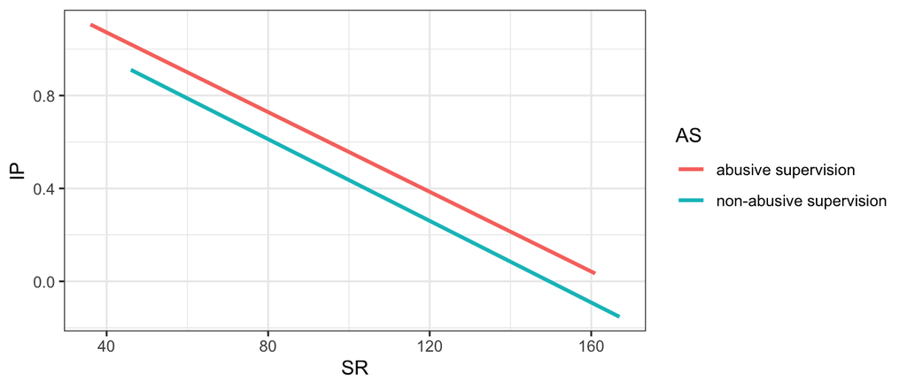

The slope of the relationship between subordinate retaliation and injustice perception is not different for abusive supervision and non-abusive supervision contexts (AS = abusive supervision; IP = injustice perception; SR = subordinate retaliation).

# Discussion and Conclusion

They are usually dissociated but the purpose of the current paper was mainly to display the structure of a research paper rather than actually writing a paper. In this section, authors are presenting potential explanation of the effect/non-effect obtained. Limitations regarding the data collection and data analyses can also been added in these sections. Here, the data being randomly generated, there is nothing really to say.

# References

Liang, L. H., Brown, D. J., Lian, H., Hanig, S., Ferris, D. L., & Keeping, L. M. (2018). Righting a wrong: Retaliation on a voodoo doll symbolizing an abusive supervisor restores justice. The Leadership Quarterly, 29(4), 443-456.

The jamovi project (2021). jamovi (Version 1.6). Retrieved from https://www.jamovi.org.

R Core Team (2020). R: A Language and environment for statistical computing (Version 4.0). Retrieved from https://cran.r-project.org.